# Risk Factor Analysis

## Outcome Variable

**Outcome Variable:** whz

## Predictor Variables

**Intervention Variable:** vagbrth

**Adjustment Set:**

- arm
- sex
- W_mage
- meducyrs
- feducyrs
- hhwealth_quart
- W_mhtcm
- W_mwtkg
- W_mbmi
- single
- W_nrooms
- brthmon
- W_parity
- impfloor
- delta_W_mage
- delta_meducyrs
- delta_feducyrs
- delta_hhwealth_quart
- delta_W_mhtcm
- delta_W_mwtkg
- delta_W_mbmi
- delta_single
- delta_W_nrooms
- delta_brthmon
- delta_W_parity
- delta_impfloor

## Stratifying Variables

The analysis was stratified on these variable(s):

- agecat
- studyid
- country

## Data Summary

| agecat | studyid | country | vagbrth | n_cell | n | outcome_variable |
| --- | --- | --- | --- | --- | --- | --- |
| Birth | CMC-V-BCS-2002 | INDIA | 0 | 10 | 86 | whz |
| Birth | CMC-V-BCS-2002 | INDIA | 1 | 76 | 86 | whz |
| Birth | IRC | INDIA | 0 | 66 | 343 | whz |
| Birth | IRC | INDIA | 1 | 277 | 343 | whz |
| Birth | JiVitA-3 | BANGLADESH | 0 | 500 | 17985 | whz |
| Birth | JiVitA-3 | BANGLADESH | 1 | 17485 | 17985 | whz |
| Birth | JiVitA-4 | BANGLADESH | 0 | 71 | 2395 | whz |
| Birth | JiVitA-4 | BANGLADESH | 1 | 2324 | 2395 | whz |
| Birth | NIH-Crypto | BANGLADESH | 0 | 184 | 465 | whz |
| Birth | NIH-Crypto | BANGLADESH | 1 | 281 | 465 | whz |
| Birth | PROBIT | BELARUS | 0 | 1591 | 13817 | whz |
| Birth | PROBIT | BELARUS | 1 | 12226 | 13817 | whz |
| Birth | PROVIDE | BANGLADESH | 0 | 108 | 532 | whz |
| Birth | PROVIDE | BANGLADESH | 1 | 424 | 532 | whz |
| Birth | ZVITAMBO | ZIMBABWE | 0 | 1100 | 12814 | whz |
| Birth | ZVITAMBO | ZIMBABWE | 1 | 11714 | 12814 | whz |
| 6 months | CMC-V-BCS-2002 | INDIA | 0 | 25 | 368 | whz |
| 6 months | CMC-V-BCS-2002 | INDIA | 1 | 343 | 368 | whz |
| 6 months | IRC | INDIA | 0 | 68 | 408 | whz |
| 6 months | IRC | INDIA | 1 | 340 | 408 | whz |
| 6 months | JiVitA-3 | BANGLADESH | 0 | 1075 | 16705 | whz |
| 6 months | JiVitA-3 | BANGLADESH | 1 | 15630 | 16705 | whz |
| 6 months | JiVitA-4 | BANGLADESH | 0 | 337 | 4056 | whz |
| 6 months | JiVitA-4 | BANGLADESH | 1 | 3719 | 4056 | whz |
| 6 months | NIH-Crypto | BANGLADESH | 0 | 187 | 457 | whz |
| 6 months | NIH-Crypto | BANGLADESH | 1 | 270 | 457 | whz |
| 6 months | PROBIT | BELARUS | 0 | 1797 | 15757 | whz |
| 6 months | PROBIT | BELARUS | 1 | 13960 | 15757 | whz |
| 6 months | PROVIDE | BANGLADESH | 0 | 139 | 603 | whz |
| 6 months | PROVIDE | BANGLADESH | 1 | 464 | 603 | whz |
| 6 months | TanzaniaChild2 | TANZANIA, UNITED REPUBLIC OF | 0 | 189 | 2004 | whz |
| 6 months | TanzaniaChild2 | TANZANIA, UNITED REPUBLIC OF | 1 | 1815 | 2004 | whz |
| 6 months | ZVITAMBO | ZIMBABWE | 0 | 721 | 8437 | whz |
| 6 months | ZVITAMBO | ZIMBABWE | 1 | 7716 | 8437 | whz |
| 24 months | CMC-V-BCS-2002 | INDIA | 0 | 25 | 372 | whz |
| 24 months | CMC-V-BCS-2002 | INDIA | 1 | 347 | 372 | whz |
| 24 months | IRC | INDIA | 0 | 69 | 409 | whz |
| 24 months | IRC | INDIA | 1 | 340 | 409 | whz |
| 24 months | JiVitA-3 | BANGLADESH | 0 | 475 | 8555 | whz |
| 24 months | JiVitA-3 | BANGLADESH | 1 | 8080 | 8555 | whz |
| 24 months | JiVitA-4 | BANGLADESH | 0 | 323 | 4008 | whz |
| 24 months | JiVitA-4 | BANGLADESH | 1 | 3685 | 4008 | whz |
| 24 months | NIH-Crypto | BANGLADESH | 0 | 99 | 260 | whz |
| 24 months | NIH-Crypto | BANGLADESH | 1 | 161 | 260 | whz |
| 24 months | PROBIT | BELARUS | 0 | 463 | 3970 | whz |
| 24 months | PROBIT | BELARUS | 1 | 3507 | 3970 | whz |
| 24 months | PROVIDE | BANGLADESH | 0 | 137 | 579 | whz |
| 24 months | PROVIDE | BANGLADESH | 1 | 442 | 579 | whz |
| 24 months | TanzaniaChild2 | TANZANIA, UNITED REPUBLIC OF | 0 | 2 | 6 | whz |
| 24 months | TanzaniaChild2 | TANZANIA, UNITED REPUBLIC OF | 1 | 4 | 6 | whz |
| 24 months | ZVITAMBO | ZIMBABWE | 0 | 28 | 426 | whz |
| 24 months | ZVITAMBO | ZIMBABWE | 1 | 398 | 426 | whz |

The following strata were considered:

- agecat: 24 months, studyid: CMC-V-BCS-2002, country: INDIA
- agecat: 24 months, studyid: IRC, country: INDIA
- agecat: 24 months, studyid: JiVitA-3, country: BANGLADESH
- agecat: 24 months, studyid: JiVitA-4, country: BANGLADESH
- agecat: 24 months, studyid: NIH-Crypto, country: BANGLADESH
- agecat: 24 months, studyid: PROBIT, country: BELARUS
- agecat: 24 months, studyid: PROVIDE, country: BANGLADESH
- agecat: 24 months, studyid: TanzaniaChild2, country: TANZANIA, UNITED REPUBLIC OF
- agecat: 24 months, studyid: ZVITAMBO, country: ZIMBABWE
- agecat: 6 months, studyid: CMC-V-BCS-2002, country: INDIA
- agecat: 6 months, studyid: IRC, country: INDIA
- agecat: 6 months, studyid: JiVitA-3, country: BANGLADESH
- agecat: 6 months, studyid: JiVitA-4, country: BANGLADESH
- agecat: 6 months, studyid: NIH-Crypto, country: BANGLADESH
- agecat: 6 months, studyid: PROBIT, country: BELARUS
- agecat: 6 months, studyid: PROVIDE, country: BANGLADESH
- agecat: 6 months, studyid: TanzaniaChild2, country: TANZANIA, UNITED REPUBLIC OF
- agecat: 6 months, studyid: ZVITAMBO, country: ZIMBABWE
- agecat: Birth, studyid: CMC-V-BCS-2002, country: INDIA
- agecat: Birth, studyid: IRC, country: INDIA
- agecat: Birth, studyid: JiVitA-3, country: BANGLADESH
- agecat: Birth, studyid: JiVitA-4, country: BANGLADESH
- agecat: Birth, studyid: NIH-Crypto, country: BANGLADESH
- agecat: Birth, studyid: PROBIT, country: BELARUS
- agecat: Birth, studyid: PROVIDE, country: BANGLADESH
- agecat: Birth, studyid: ZVITAMBO, country: ZIMBABWE

### Dropped Strata

Some strata were dropped due to rare outcomes:

- agecat: 24 months, studyid: TanzaniaChild2, country: TANZANIA, UNITED REPUBLIC OF

## Methods Detail

We’re interested in the causal parameters $E[Y_a]$ for all values of $a \in \mathcal{A}$. These parameters represent the mean outcome if, possibly contrary to fact, we intervened to set all units to have $A=a$. Under the randomization and positivity assumptions, these are identified by the statistical parameters $\psi_a=E_W[E_{Y|A,W}(Y|A=a,W)]$. In addition, we’re interested in the mean of $Y$, $E[Y]$ under no intervention (the observed mean). We will estimate these parameters by using SuperLearner to fit the relevant likelihood factors – $E_{Y|A,W}(Y|A=a,W)$ and $p(A=a|W)$, and then updating our likelihood fit using a joint TMLE.

For unadjusted analyses ($W=\{\}$), initial likelihoods were estimated using Lrnr_glm to estimate the simple $E(Y|A)$ and Lrnr_mean to estimate $p(A)$. For adjusted analyses, a small library containing Lrnr_glmnet, Lrnr_xgboost, and Lrnr_mean was used.

Having estimated these parameters, we will then use the delta method to estimate relative risks and attributable risks relative to a prespecified baseline level of $A$.

# Results Detail

## Results Plots

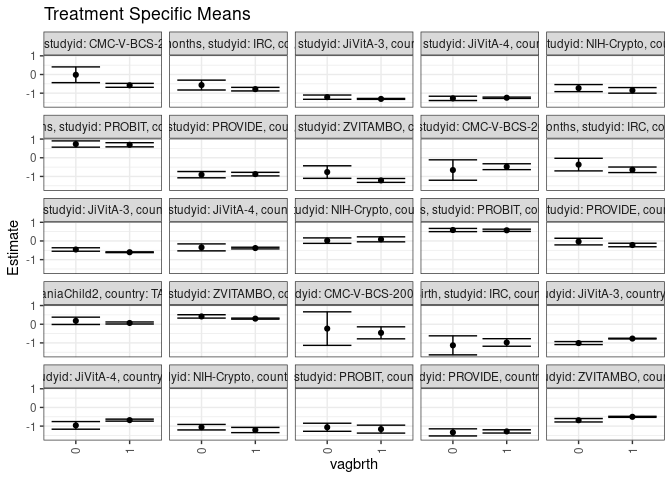

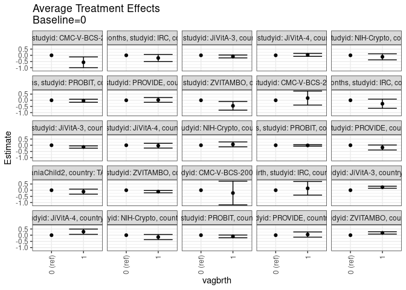

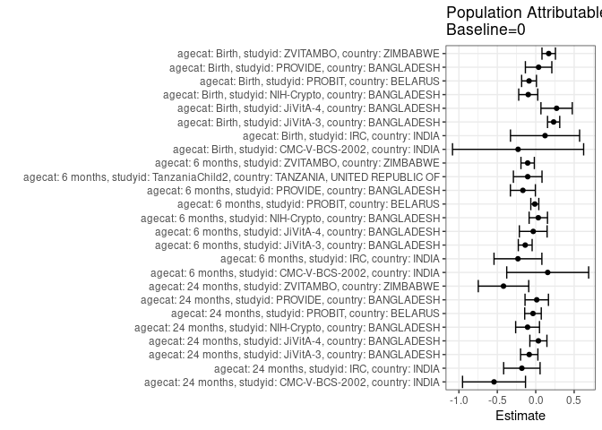

## Results Table

### Parameter: TSM

| agecat | studyid | country | intervention_level | baseline_level | estimate | ci_lower | ci_upper |
| --- | --- | --- | --- | --- | --- | --- | --- |
| Birth | CMC-V-BCS-2002 | INDIA | 0 | NA | -0.2349355 | -1.1333674 | 0.6634965 |
| Birth | CMC-V-BCS-2002 | INDIA | 1 | NA | -0.4614936 | -0.7836368 | -0.1393505 |
| Birth | IRC | INDIA | 0 | NA | -1.1316775 | -1.6415783 | -0.6217767 |
| Birth | IRC | INDIA | 1 | NA | -0.9785128 | -1.1798340 | -0.7771916 |
| Birth | JiVitA-3 | BANGLADESH | 0 | NA | -1.0103114 | -1.0909468 | -0.9296759 |
| Birth | JiVitA-3 | BANGLADESH | 1 | NA | -0.7693642 | -0.7887375 | -0.7499909 |
| Birth | JiVitA-4 | BANGLADESH | 0 | NA | -0.9606423 | -1.1654316 | -0.7558529 |
| Birth | JiVitA-4 | BANGLADESH | 1 | NA | -0.6793950 | -0.7328943 | -0.6258957 |
| Birth | NIH-Crypto | BANGLADESH | 0 | NA | -1.0574547 | -1.2045097 | -0.9103996 |
| Birth | NIH-Crypto | BANGLADESH | 1 | NA | -1.2094934 | -1.3495013 | -1.0694854 |
| Birth | PROBIT | BELARUS | 0 | NA | -1.0620844 | -1.2776860 | -0.8464828 |
| Birth | PROBIT | BELARUS | 1 | NA | -1.1612237 | -1.3737802 | -0.9486672 |
| Birth | PROVIDE | BANGLADESH | 0 | NA | -1.3357697 | -1.5260804 | -1.1454589 |
| Birth | PROVIDE | BANGLADESH | 1 | NA | -1.2843510 | -1.3707987 | -1.1979032 |
| Birth | ZVITAMBO | ZIMBABWE | 0 | NA | -0.6856493 | -0.7771824 | -0.5941162 |
| Birth | ZVITAMBO | ZIMBABWE | 1 | NA | -0.5026907 | -0.5298296 | -0.4755519 |
| 6 months | CMC-V-BCS-2002 | INDIA | 0 | NA | -0.6581940 | -1.2050710 | -0.1113171 |
| 6 months | CMC-V-BCS-2002 | INDIA | 1 | NA | -0.4789909 | -0.6364355 | -0.3215464 |
| 6 months | IRC | INDIA | 0 | NA | -0.3673012 | -0.7050722 | -0.0295301 |
| 6 months | IRC | INDIA | 1 | NA | -0.6454519 | -0.7933957 | -0.4975080 |
| 6 months | JiVitA-3 | BANGLADESH | 0 | NA | -0.4566331 | -0.5500618 | -0.3632045 |
| 6 months | JiVitA-3 | BANGLADESH | 1 | NA | -0.6025582 | -0.6224093 | -0.5827071 |
| 6 months | JiVitA-4 | BANGLADESH | 0 | NA | -0.3431791 | -0.5300274 | -0.1563307 |
| 6 months | JiVitA-4 | BANGLADESH | 1 | NA | -0.3798614 | -0.4250102 | -0.3347125 |
| 6 months | NIH-Crypto | BANGLADESH | 0 | NA | 0.0182020 | -0.1274393 | 0.1638433 |
| 6 months | NIH-Crypto | BANGLADESH | 1 | NA | 0.0888333 | -0.0449470 | 0.2226136 |
| 6 months | PROBIT | BELARUS | 0 | NA | 0.5862515 | 0.5012592 | 0.6712439 |
| 6 months | PROBIT | BELARUS | 1 | NA | 0.5731057 | 0.5134443 | 0.6327671 |
| 6 months | PROVIDE | BANGLADESH | 0 | NA | -0.0319390 | -0.2089665 | 0.1450885 |
| 6 months | PROVIDE | BANGLADESH | 1 | NA | -0.2153259 | -0.3107424 | -0.1199094 |
| 6 months | TanzaniaChild2 | TANZANIA, UNITED REPUBLIC OF | 0 | NA | 0.1815159 | -0.0142458 | 0.3772775 |
| 6 months | TanzaniaChild2 | TANZANIA, UNITED REPUBLIC OF | 1 | NA | 0.0661155 | 0.0109421 | 0.1212889 |
| 6 months | ZVITAMBO | ZIMBABWE | 0 | NA | 0.4168318 | 0.3260856 | 0.5075781 |
| 6 months | ZVITAMBO | ZIMBABWE | 1 | NA | 0.2986603 | 0.2717442 | 0.3255765 |
| 24 months | CMC-V-BCS-2002 | INDIA | 0 | NA | -0.0142793 | -0.4364209 | 0.4078622 |
| 24 months | CMC-V-BCS-2002 | INDIA | 1 | NA | -0.5797975 | -0.6844042 | -0.4751909 |
| 24 months | IRC | INDIA | 0 | NA | -0.5652668 | -0.8298780 | -0.3006556 |
| 24 months | IRC | INDIA | 1 | NA | -0.7838230 | -0.8798369 | -0.6878091 |
| 24 months | JiVitA-3 | BANGLADESH | 0 | NA | -1.2138164 | -1.3279682 | -1.0996647 |
| 24 months | JiVitA-3 | BANGLADESH | 1 | NA | -1.3073998 | -1.3314846 | -1.2833150 |
| 24 months | JiVitA-4 | BANGLADESH | 0 | NA | -1.2778308 | -1.3935922 | -1.1620693 |
| 24 months | JiVitA-4 | BANGLADESH | 1 | NA | -1.2443051 | -1.2801399 | -1.2084703 |
| 24 months | NIH-Crypto | BANGLADESH | 0 | NA | -0.7279630 | -0.9168064 | -0.5391195 |
| 24 months | NIH-Crypto | BANGLADESH | 1 | NA | -0.8487715 | -0.9991892 | -0.6983538 |
| 24 months | PROBIT | BELARUS | 0 | NA | 0.7339765 | 0.5661048 | 0.9018482 |
| 24 months | PROBIT | BELARUS | 1 | NA | 0.6944121 | 0.5831220 | 0.8057022 |
| 24 months | PROVIDE | BANGLADESH | 0 | NA | -0.9057828 | -1.0736583 | -0.7379074 |
| 24 months | PROVIDE | BANGLADESH | 1 | NA | -0.8772490 | -0.9726589 | -0.7818391 |
| 24 months | ZVITAMBO | ZIMBABWE | 0 | NA | -0.7668797 | -1.1023990 | -0.4313604 |
| 24 months | ZVITAMBO | ZIMBABWE | 1 | NA | -1.2148632 | -1.3188609 | -1.1108654 |

### Parameter: E(Y)

| agecat | studyid | country | intervention_level | baseline_level | estimate | ci_lower | ci_upper |
| --- | --- | --- | --- | --- | --- | --- | --- |
| Birth | CMC-V-BCS-2002 | INDIA | NA | NA | -0.4648256 | -0.7643210 | -0.1653302 |
| Birth | IRC | INDIA | NA | NA | -1.0105831 | -1.1973019 | -0.8238643 |
| Birth | JiVitA-3 | BANGLADESH | NA | NA | -0.7774729 | -0.7964631 | -0.7584827 |
| Birth | JiVitA-4 | BANGLADESH | NA | NA | -0.6890188 | -0.7414800 | -0.6365575 |
| Birth | NIH-Crypto | BANGLADESH | NA | NA | -1.1549785 | -1.2577390 | -1.0522180 |
| Birth | PROBIT | BELARUS | NA | NA | -1.1491782 | -1.3593933 | -0.9389630 |
| Birth | PROVIDE | BANGLADESH | NA | NA | -1.2984586 | -1.3752758 | -1.2216415 |
| Birth | ZVITAMBO | ZIMBABWE | NA | NA | -0.5168886 | -0.5428625 | -0.4909146 |
| 6 months | CMC-V-BCS-2002 | INDIA | NA | NA | -0.5026766 | -0.6536848 | -0.3516685 |
| 6 months | IRC | INDIA | NA | NA | -0.5989297 | -0.7344491 | -0.4634104 |
| 6 months | JiVitA-3 | BANGLADESH | NA | NA | -0.5935070 | -0.6130727 | -0.5739413 |
| 6 months | JiVitA-4 | BANGLADESH | NA | NA | -0.3758037 | -0.4184544 | -0.3331531 |
| 6 months | NIH-Crypto | BANGLADESH | NA | NA | 0.0515536 | -0.0469240 | 0.1500313 |
| 6 months | PROBIT | BELARUS | NA | NA | 0.5741099 | 0.5141290 | 0.6340908 |
| 6 months | PROVIDE | BANGLADESH | NA | NA | -0.1990907 | -0.2817968 | -0.1163845 |
| 6 months | TanzaniaChild2 | TANZANIA, UNITED REPUBLIC OF | NA | NA | 0.0769382 | 0.0241090 | 0.1297674 |
| 6 months | ZVITAMBO | ZIMBABWE | NA | NA | 0.3116179 | 0.2858347 | 0.3374010 |
| 24 months | CMC-V-BCS-2002 | INDIA | NA | NA | -0.5571505 | -0.6585247 | -0.4557763 |
| 24 months | IRC | INDIA | NA | NA | -0.7458150 | -0.8368180 | -0.6548120 |
| 24 months | JiVitA-3 | BANGLADESH | NA | NA | -1.2983928 | -1.3216893 | -1.2750962 |
| 24 months | JiVitA-4 | BANGLADESH | NA | NA | -1.2433658 | -1.2774681 | -1.2092634 |
| 24 months | NIH-Crypto | BANGLADESH | NA | NA | -0.8343077 | -0.9482310 | -0.7203844 |
| 24 months | PROBIT | BELARUS | NA | NA | 0.6981406 | 0.5843775 | 0.8119038 |
| 24 months | PROVIDE | BANGLADESH | NA | NA | -0.8928670 | -0.9755153 | -0.8102187 |
| 24 months | ZVITAMBO | ZIMBABWE | NA | NA | -1.1864319 | -1.2865891 | -1.0862748 |

### Parameter: ATE

| agecat | studyid | country | intervention_level | baseline_level | estimate | ci_lower | ci_upper |
| --- | --- | --- | --- | --- | --- | --- | --- |
| Birth | CMC-V-BCS-2002 | INDIA | 0 | 0 | 0.0000000 | 0.0000000 | 0.0000000 |
| Birth | CMC-V-BCS-2002 | INDIA | 1 | 0 | -0.2265581 | -1.1830167 | 0.7299004 |
| Birth | IRC | INDIA | 0 | 0 | 0.0000000 | 0.0000000 | 0.0000000 |
| Birth | IRC | INDIA | 1 | 0 | 0.1531647 | -0.3954494 | 0.7017788 |
| Birth | JiVitA-3 | BANGLADESH | 0 | 0 | 0.0000000 | 0.0000000 | 0.0000000 |
| Birth | JiVitA-3 | BANGLADESH | 1 | 0 | 0.2409472 | 0.1589282 | 0.3229661 |
| Birth | JiVitA-4 | BANGLADESH | 0 | 0 | 0.0000000 | 0.0000000 | 0.0000000 |
| Birth | JiVitA-4 | BANGLADESH | 1 | 0 | 0.2812472 | 0.0691495 | 0.4933450 |
| Birth | NIH-Crypto | BANGLADESH | 0 | 0 | 0.0000000 | 0.0000000 | 0.0000000 |
| Birth | NIH-Crypto | BANGLADESH | 1 | 0 | -0.1520387 | -0.3564378 | 0.0523604 |
| Birth | PROBIT | BELARUS | 0 | 0 | 0.0000000 | 0.0000000 | 0.0000000 |
| Birth | PROBIT | BELARUS | 1 | 0 | -0.0991393 | -0.2083617 | 0.0100830 |
| Birth | PROVIDE | BANGLADESH | 0 | 0 | 0.0000000 | 0.0000000 | 0.0000000 |
| Birth | PROVIDE | BANGLADESH | 1 | 0 | 0.0514187 | -0.1583115 | 0.2611490 |
| Birth | ZVITAMBO | ZIMBABWE | 0 | 0 | 0.0000000 | 0.0000000 | 0.0000000 |
| Birth | ZVITAMBO | ZIMBABWE | 1 | 0 | 0.1829586 | 0.0876116 | 0.2783055 |
| 6 months | CMC-V-BCS-2002 | INDIA | 0 | 0 | 0.0000000 | 0.0000000 | 0.0000000 |
| 6 months | CMC-V-BCS-2002 | INDIA | 1 | 0 | 0.1792031 | -0.3862564 | 0.7446626 |
| 6 months | IRC | INDIA | 0 | 0 | 0.0000000 | 0.0000000 | 0.0000000 |
| 6 months | IRC | INDIA | 1 | 0 | -0.2781507 | -0.6477112 | 0.0914099 |
| 6 months | JiVitA-3 | BANGLADESH | 0 | 0 | 0.0000000 | 0.0000000 | 0.0000000 |
| 6 months | JiVitA-3 | BANGLADESH | 1 | 0 | -0.1459250 | -0.2395934 | -0.0522567 |
| 6 months | JiVitA-4 | BANGLADESH | 0 | 0 | 0.0000000 | 0.0000000 | 0.0000000 |
| 6 months | JiVitA-4 | BANGLADESH | 1 | 0 | -0.0366823 | -0.2291681 | 0.1558034 |
| 6 months | NIH-Crypto | BANGLADESH | 0 | 0 | 0.0000000 | 0.0000000 | 0.0000000 |
| 6 months | NIH-Crypto | BANGLADESH | 1 | 0 | 0.0706313 | -0.1269295 | 0.2681921 |
| 6 months | PROBIT | BELARUS | 0 | 0 | 0.0000000 | 0.0000000 | 0.0000000 |
| 6 months | PROBIT | BELARUS | 1 | 0 | -0.0131458 | -0.0719528 | 0.0456612 |
| 6 months | PROVIDE | BANGLADESH | 0 | 0 | 0.0000000 | 0.0000000 | 0.0000000 |
| 6 months | PROVIDE | BANGLADESH | 1 | 0 | -0.1833869 | -0.3856641 | 0.0188904 |
| 6 months | TanzaniaChild2 | TANZANIA, UNITED REPUBLIC OF | 0 | 0 | 0.0000000 | 0.0000000 | 0.0000000 |
| 6 months | TanzaniaChild2 | TANZANIA, UNITED REPUBLIC OF | 1 | 0 | -0.1154004 | -0.3191520 | 0.0883512 |
| 6 months | ZVITAMBO | ZIMBABWE | 0 | 0 | 0.0000000 | 0.0000000 | 0.0000000 |
| 6 months | ZVITAMBO | ZIMBABWE | 1 | 0 | -0.1181715 | -0.2127134 | -0.0236295 |
| 24 months | CMC-V-BCS-2002 | INDIA | 0 | 0 | 0.0000000 | 0.0000000 | 0.0000000 |
| 24 months | CMC-V-BCS-2002 | INDIA | 1 | 0 | -0.5655182 | -1.0007044 | -0.1303320 |
| 24 months | IRC | INDIA | 0 | 0 | 0.0000000 | 0.0000000 | 0.0000000 |
| 24 months | IRC | INDIA | 1 | 0 | -0.2185562 | -0.5003260 | 0.0632136 |
| 24 months | JiVitA-3 | BANGLADESH | 0 | 0 | 0.0000000 | 0.0000000 | 0.0000000 |
| 24 months | JiVitA-3 | BANGLADESH | 1 | 0 | -0.0935834 | -0.2101941 | 0.0230274 |
| 24 months | JiVitA-4 | BANGLADESH | 0 | 0 | 0.0000000 | 0.0000000 | 0.0000000 |
| 24 months | JiVitA-4 | BANGLADESH | 1 | 0 | 0.0335257 | -0.0862819 | 0.1533334 |
| 24 months | NIH-Crypto | BANGLADESH | 0 | 0 | 0.0000000 | 0.0000000 | 0.0000000 |
| 24 months | NIH-Crypto | BANGLADESH | 1 | 0 | -0.1208086 | -0.3649021 | 0.1232850 |
| 24 months | PROBIT | BELARUS | 0 | 0 | 0.0000000 | 0.0000000 | 0.0000000 |
| 24 months | PROBIT | BELARUS | 1 | 0 | -0.0395644 | -0.1615972 | 0.0824684 |
| 24 months | PROVIDE | BANGLADESH | 0 | 0 | 0.0000000 | 0.0000000 | 0.0000000 |
| 24 months | PROVIDE | BANGLADESH | 1 | 0 | 0.0285338 | -0.1631081 | 0.2201758 |
| 24 months | ZVITAMBO | ZIMBABWE | 0 | 0 | 0.0000000 | 0.0000000 | 0.0000000 |
| 24 months | ZVITAMBO | ZIMBABWE | 1 | 0 | -0.4479835 | -0.7995344 | -0.0964325 |

### Parameter: PAR

| agecat | studyid | country | intervention_level | baseline_level | estimate | ci_lower | ci_upper |
| --- | --- | --- | --- | --- | --- | --- | --- |
| Birth | CMC-V-BCS-2002 | INDIA | 0 | NA | -0.2298901 | -1.0831444 | 0.6233642 |
| Birth | IRC | INDIA | 0 | NA | 0.1210944 | -0.3287335 | 0.5709223 |
| Birth | JiVitA-3 | BANGLADESH | 0 | NA | 0.2328385 | 0.1534828 | 0.3121941 |
| Birth | JiVitA-4 | BANGLADESH | 0 | NA | 0.2716235 | 0.0677711 | 0.4754759 |
| Birth | NIH-Crypto | BANGLADESH | 0 | NA | -0.0975238 | -0.2214230 | 0.0263753 |
| Birth | PROBIT | BELARUS | 0 | NA | -0.0870938 | -0.1834787 | 0.0092911 |
| Birth | PROVIDE | BANGLADESH | 0 | NA | 0.0373110 | -0.1346925 | 0.2093146 |
| Birth | ZVITAMBO | ZIMBABWE | 0 | NA | 0.1687607 | 0.0811196 | 0.2564018 |
| 6 months | CMC-V-BCS-2002 | INDIA | 0 | NA | 0.1555174 | -0.3775548 | 0.6885896 |
| 6 months | IRC | INDIA | 0 | NA | -0.2316286 | -0.5430807 | 0.0798236 |
| 6 months | JiVitA-3 | BANGLADESH | 0 | NA | -0.1368739 | -0.2268925 | -0.0468553 |
| 6 months | JiVitA-4 | BANGLADESH | 0 | NA | -0.0326247 | -0.2132671 | 0.1480177 |
| 6 months | NIH-Crypto | BANGLADESH | 0 | NA | 0.0333516 | -0.0861207 | 0.1528240 |
| 6 months | PROBIT | BELARUS | 0 | NA | -0.0121416 | -0.0642461 | 0.0399629 |
| 6 months | PROVIDE | BANGLADESH | 0 | NA | -0.1671516 | -0.3295734 | -0.0047299 |
| 6 months | TanzaniaChild2 | TANZANIA, UNITED REPUBLIC OF | 0 | NA | -0.1045776 | -0.2907013 | 0.0815460 |
| 6 months | ZVITAMBO | ZIMBABWE | 0 | NA | -0.1052140 | -0.1922108 | -0.0182172 |
| 24 months | CMC-V-BCS-2002 | INDIA | 0 | NA | -0.5428712 | -0.9526457 | -0.1330967 |
| 24 months | IRC | INDIA | 0 | NA | -0.1805482 | -0.4175640 | 0.0564676 |
| 24 months | JiVitA-3 | BANGLADESH | 0 | NA | -0.0845763 | -0.1971551 | 0.0280024 |
| 24 months | JiVitA-4 | BANGLADESH | 0 | NA | 0.0344650 | -0.0766122 | 0.1455423 |
| 24 months | NIH-Crypto | BANGLADESH | 0 | NA | -0.1063447 | -0.2614281 | 0.0487387 |
| 24 months | PROBIT | BELARUS | 0 | NA | -0.0358359 | -0.1435148 | 0.0718431 |
| 24 months | PROVIDE | BANGLADESH | 0 | NA | 0.0129158 | -0.1394554 | 0.1652871 |
| 24 months | ZVITAMBO | ZIMBABWE | 0 | NA | -0.4195522 | -0.7479860 | -0.0911184 |